# Data Load

```python
import pandas as pd

df = pd.read_csv('https://storage.googleapis.com/datalynn-datasets/interview-challenge/technology/IBM_IoT/IoT2.csv')
```

# Question 1

**(Data Manipulation & Cleaning)**  
Given the `IoT_data` table, which is laden with missing values and potential anomalies:

- Identify and handle missing values for the machine_temperature and machine_vibration columns.
- Spot and handle any potential outliers in the product_quality score.

## Solution:

### Hints:

1. Use Pandas for Data Manipulation

Pandas is a powerful Python library for data manipulation and analysis. Use it to load your dataset into a DataFrame for easier handling of missing values and outliers. Functions like `pd.read_csv()` and `DataFrame.fillna()` will be very handy.

2. Identify Missing Values and Outliers through Statistical Methods

For missing values, you can use the `DataFrame.isna().sum()` function to count the number of missing entries for each column. For identifying outliers, consider statistical methods like Z-score or the Inter-Quartile Range (IQR). Pandas' `quantile()` function can help you calculate Q1 and Q3, essential values for the IQR method.

3. Handle Missing Values and Outliers Appropriately

Once missing values and outliers are identified, decide on the most appropriate handling method based on the nature of your dataset. For missing values, you might choose to remove those entries, or you could impute them with the mean, median, or mode. For outliers, options could include removing them or capping them to a specific range. Use Pandas' DataFrame manipulation methods, like `fillna()` or `where()`, to implement these solutions.

```python
# Import Necessary Libraries
import pandas as pd
import numpy as np

# Step 1: Identify and Handle Missing Values

# For 'machine_temperature'

# Count the number of missing values in the machine_temperature column
df_1 = df.copy(deep=True)
missing_temp = df_1['machine_temperature'].isna().sum()
print(f"Missing values in machine_temperature: {missing_temp}")

# Impute missing values with the mean of the column
mean_temp = df_1['machine_temperature'].mean()
df_1['machine_temperature'].fillna(mean_temp, inplace=True)

# For 'machine_vibration'

# Count the number of missing values in the machine_vibration column
missing_vibration = df_1['machine_vibration'].isna().sum()
print(f"Missing values in machine_vibration: {missing_vibration}")

# Impute missing values with the mean of the column
mean_vibration = df_1['machine_vibration'].mean()
df_1['machine_vibration'].fillna(mean_vibration, inplace=True)

# Step 2: Spot and Handle Outliers in 'product_quality'

# Identify outliers using IQR method

# Compute the first quartile (Q1) and third quartile (Q3) of the column
Q1 = df_1['product_quality'].quantile(0.25)
Q3 = df_1['product_quality'].quantile(0.75)

# Compute the Inter-Quartile Range (IQR)
IQR = Q3 - Q1

# Define bounds for the outliers
lower_bound = Q1 - 1.5 * IQR
upper_bound = Q3 + 1.5 * IQR

# Identify the outliers
outliers = df_1[(df_1['product_quality'] < lower_bound) | (df_1['product_quality'] > upper_bound)]

# Print the number of identified outliers
print(f"Identified {len(outliers)} outliers in product_quality.")

# Handle outliers by capping them to the IQR bounds
df_1['product_quality'] = np.where(df_1['product_quality'] < lower_bound, lower_bound, df_1['product_quality'])
df_1['product_quality'] = np.where(df_1['product_quality'] > upper_bound, upper_bound, df_1['product_quality'])

# Your data should now be cleaned and ready for analysis or model training
```

```
Missing values in machine_temperature: 509
Missing values in machine_vibration: 360
Identified 67 outliers in product_quality.
```

# Question 2

**(Probability and Statistics)**  
From the `IoT_data`, using data from devices located at 'location_code_X':

- Calculate the probability that a product is defective.
- Based on machine_temperature, can you infer if there's a significant difference in temperature when a product turns out to be defective?

## Solution:

### Hints:

1. **Data Filtering**: Start by filtering the dataset to only include records where the `device_location` is 'location_code_X'.
2. **Calculate Defect Probability**: Use the filtered data to calculate the probability of a product being defective. The probability can be calculated as the ratio of defective products to the total number of products.
3. **Temperature Significance Testing**: Use a t-test to compare the `machine_temperature` between defective and non-defective products in the filtered dataset. This will help you assess if there's a significant difference in temperature when a product turns out to be defective.

```python
# Import necessary libraries
import pandas as pd
from scipy import stats

# Load the Data into a Pandas DataFrame
df_2 = df.copy(deep=True)
# Step 1: Filter data for 'location_code_X'. We take location 1 as an example
filtered_data = df_2[df_2['device_location'] == 'location_code_1']

# Step 2: Calculate the probability that a product is defective in 'location_code_X'
total_products = len(filtered_data)
defective_products = len(filtered_data[filtered_data['defective'] == 1])

probability_defective = defective_products / total_products
print(f"The probability that a product is defective at location_code_X is: {probability_defective}")

# Step 3: Analyze if there's a significant difference in machine_temperature when a product is defective
# We'll use a t-test for this purpose

# Gather temperatures for defective and non-defective products
temp_defective = filtered_data[filtered_data['defective'] == 1]['machine_temperature']
temp_non_defective = filtered_data[filtered_data['defective'] == 0]['machine_temperature']

# Perform t-test
t_stat, p_value = stats.ttest_ind(temp_defective, temp_non_defective, equal_var=False)

# Check if the p_value is less than 0.05 for 95% confidence level
if p_value < 0.05:
    print("There is a significant difference in machine temperature when a product is defective.")
else:
    print("There is no significant difference in machine temperature when a product is defective.")
```

```
The probability that a product is defective at location_code_X is: 0.6048780487804878
There is no significant difference in machine temperature when a product is defective.
```

# Question 3

**(Machine Learning & Modeling)**  
Using the `IoT_data`, we want to create a predictive model:

- Set 'defective' as the target variable.
- Use relevant features from the dataset to predict if a product will be defective.
- Once the model is built, explain the importance of each feature in predicting the defectiveness of a product.

## Solution:

### Hints:

1. Data Preprocessing

Before feeding the data into a machine learning model, consider preprocessing steps like one-hot encoding for categorical variables, dropping irrelevant columns like timestamps, and normalization of continuous features if needed.

2. Feature Selection and Model Choice

Be mindful of the features you choose to include in your predictive model. Consider using domain knowledge or feature importance techniques to include only those features that contribute meaningfully to the prediction of the target variable ('defective'). Given the nature of the data, you might want to consider using a tree-based algorithm like Random Forest, which can handle a mix of categorical and continuous features well and can provide feature importances.

3. Model Evaluation and Interpretation

After training the model, don't forget to evaluate its performance using metrics appropriate for binary classification problems, such as accuracy, precision, recall, and F1 score. Additionally, delve into the feature importance provided by the model to understand what factors are most influential in predicting whether a product will be defective. This is crucial for deriving actionable insights.

```python
import pandas as pd
from sklearn.model_selection import train_test_split
from sklearn.ensemble import RandomForestClassifier
from sklearn.metrics import accuracy_score, confusion_matrix, classification_report
import matplotlib.pyplot as plt
import seaborn as sns

df_3 = df.copy(deep=True)
# Step 1: Impute missing values with the mean of the column
mean_temp = df_3['machine_temperature'].mean()
df_3['machine_temperature'].fillna(mean_temp, inplace=True)

# Step 2: Impute missing values with the mean of the column
mean_vibration = df_3['machine_vibration'].mean()
df_3['machine_vibration'].fillna(mean_vibration, inplace=True)

# Step 3: Preprocess the data
# Converting Categorical features to numerical using One-Hot Encoding
df_3 = pd.get_dummies(df_3, columns=['device_id', 'supply_chain_status', 'device_location'], drop_first=True)

# Dropping 'timestamp' as it may not be directly relevant for prediction
df_3.drop('timestamp', axis=1, inplace=True)

# Step 4: Feature selection
# 'defective' is our target variable
X = df_3.drop('defective', axis=1)  # Features (all columns except 'defective')
y = df_3['defective']  # Target variable

# Step 5: Split the data into training and test sets
X_train, X_test, y_train, y_test = train_test_split(X, y, test_size=0.2, random_state=42)

# Step 6: Train the predictive model using RandomForestClassifier
clf = RandomForestClassifier(n_estimators=100, random_state=42)
clf.fit(X_train, y_train)

# Step 7: Evaluate the model's performance
y_pred = clf.predict(X_test)
print("Accuracy:", accuracy_score(y_test, y_pred))
print("Confusion Matrix:")
print(confusion_matrix(y_test, y_pred))
print("Classification Report:")
print(classification_report(y_test, y_pred))

# Step 8: Interpret feature importance
feature_importances = clf.feature_importances_
feature_names = X.columns

# Create a DataFrame for feature importances
feature_importance_df = pd.DataFrame({'Feature': feature_names, 'Importance': feature_importances})

print(feature_importance_df.head())
```

```
Accuracy: 0.998
Confusion Matrix:
[[ 799    0]
 [   4 1197]]
Classification Report:
              precision    recall  f1-score   support

           0       1.00      1.00      1.00       799
           1       1.00      1.00      1.00      1201

    accuracy                           1.00      2000
   macro avg       1.00      1.00      1.00      2000
weighted avg       1.00      1.00      1.00      2000

                Feature  Importance
0            Unnamed: 0    0.010048
1   machine_temperature    0.009850
2     machine_vibration    0.055464
3       product_quality    0.759935
4  device_battery_level    0.009638
```

### Explanation of Feature Importance:

- **machine_temperature** and **machine_vibration**: These could be crucial indicators of a machine's health. Higher or unstable values might result in defective products.
- **product_quality**: A low score could be directly related to the defectiveness of the product.
- **device_battery_level**: Lower battery levels might affect the device's performance, which could result in defective products.
- **machine_operation**: If the machine is not operational, the product is more likely to be defective.
- **supply_chain_status**, **device_id**, and **device_location**: These features could give insights into systemic issues that result in defective products.

# Question 4

**(Product Design & Analytics)**  
MachinoTech has observed that certain IoT devices report a high number of defective products. Dive deep into the `IoT_data` to:

- Identify any patterns related to specific devices or locations leading to higher defects.
- Propose a solution or strategy to mitigate these defects based on the insights drawn from the data.

## Solution:

### Hints:

1. Focus on Aggregated Metrics

Instead of diving into each record, focus on aggregated metrics like the mean or median of `defective` items for each `device_id` or `device_location`. This will help you identify problem areas more easily. Functions like `groupby()` followed by `mean()` on the DataFrame can be highly effective.

2. Use Visualizations Effectively

Visualizations can often reveal patterns that are not immediately obvious from the raw data. For example, a bar chart showing defect rates by device or location could instantly highlight problem areas. Similarly, boxplots can help you understand how variables like `machine_temperature` and `machine_vibration` are related to defects.

3. Examine Correlations with Categorical Data

Don't forget that your dataset includes categorical variables like `supply_chain_status`. You might find that certain categories are associated with higher rates of defects. Consider using pivot tables or conditional probability calculations to explore these relationships.

These hints should help you get started on identifying patterns related to specific devices or locations that lead to higher defects, and propose strategies based on those insights.

```
First few rows of the dataset:
   Unnamed: 0 device_id            timestamp  machine_temperature  \
0           0  device_1  2023-04-08 18:58:00            64.967142
1           1  device_2  2023-04-02 07:43:00            58.617357
2           2  device_3  2023-07-31 11:12:00            66.476885
3           3  device_4  2023-10-02 07:02:00            75.230299
4           4  device_5  2023-01-23 18:05:00            57.658466

   machine_vibration  product_quality  defective supply_chain_status  \
0           3.643011             2.89          1              Normal
1           4.389001             1.03          1              Normal
2           3.805238             1.11          1              Normal
3           5.220836             2.70          1              Normal
4           7.394357             1.82          1              Normal

   device_battery_level  device_location  machine_operation
0                 65.35  location_code_1                  1
1                 96.30  location_code_2                  1
2                 84.60  location_code_2                  1
3                 72.28  location_code_3                  1
4                 98.48  location_code_8                  1

Missing Values:
Unnamed: 0                0
device_id                 0
timestamp                 0
machine_temperature     509
machine_vibration       360
product_quality           0
defective                 0
supply_chain_status       0
device_battery_level      0
device_location           0
machine_operation         0
dtype: int64

Data Types:
Unnamed: 0                int64
device_id                object
timestamp                object
machine_temperature     float64
machine_vibration       float64
product_quality         float64
defective                 int64
supply_chain_status      object
device_battery_level    float64
device_location          object
machine_operation         int64
dtype: object
```

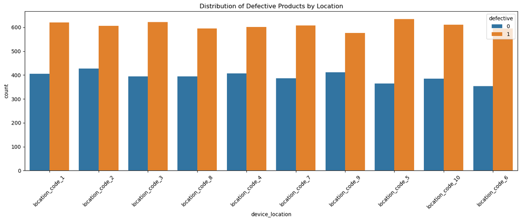

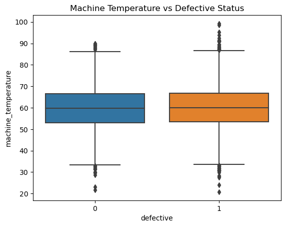

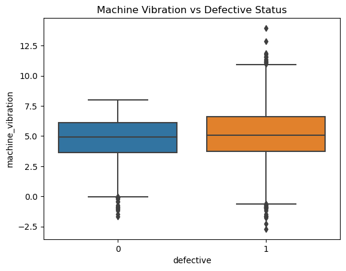

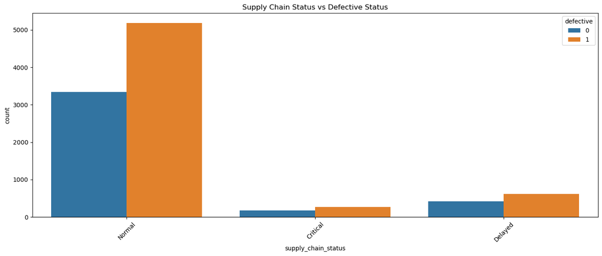

```
Device-wise Defect Ratio:
device_id
device_1       1.0
device_6251    1.0
device_6270    1.0
device_6269    1.0
device_6268    1.0
              ...
device_6690    0.0
device_669     0.0
device_300     0.0
device_3001    0.0
device_720     0.0
Name: defective, Length: 10000, dtype: float64

Location-wise Defect Ratio:
device_location
location_code_5     0.635000
location_code_6     0.627637
location_code_10    0.613454
location_code_3     0.612205
location_code_7     0.610664
location_code_1     0.604878
location_code_8     0.601010
location_code_4     0.596630
location_code_2     0.586074
location_code_9     0.584008
Name: defective, dtype: float64
```

```python
import pandas as pd
import matplotlib.pyplot as plt
import seaborn as sns

# Show the first few rows to understand the data
print("First few rows of the dataset:")
print(df.head())

# Step 1: Preliminary Analysis
# Check for any missing values
print("\nMissing Values:")
print(df.isnull().sum())

# Check data types to make sure they are as expected
print("\nData Types:")
print(df.dtypes)

# Step 2: Exploratory Data Analysis (EDA)

# 2.1 Visualize the distribution of defective products across locations
plt.figure(figsize=(14, 6))
sns.countplot(data=df, x='device_location', hue='defective')
plt.title('Distribution of Defective Products by Location')
plt.xticks(rotation=45)  # Rotate x labels to prevent overlap
plt.tight_layout()
plt.show()

# 2.2 Investigate the relationship between machine_temperature and defective status
sns.boxplot(x='defective', y='machine_temperature', data=df)
plt.title('Machine Temperature vs Defective Status')
plt.show()

# 2.3 Investigate the relationship between machine_vibration and defective status
sns.boxplot(x='defective', y='machine_vibration', data=df)
plt.title('Machine Vibration vs Defective Status')
plt.show()

# 2.4 Investigate the relationship between supply_chain_status and defective status
plt.figure(figsize=(14, 6))
sns.countplot(data=df, x='supply_chain_status', hue='defective')
plt.title('Supply Chain Status vs Defective Status')
plt.xticks(rotation=45)  # Rotate x labels to prevent overlap
plt.tight_layout()
plt.show()

# Step 3: Identify Patterns
# Identify devices with a high ratio of defective products
device_defect_ratio = df.groupby('device_id')['defective'].mean().sort_values(ascending=False)
print("\nDevice-wise Defect Ratio:")
print(device_defect_ratio)

# Identify locations with a high ratio of defective products
location_defect_ratio = df.groupby('device_location')['defective'].mean().sort_values(ascending=False)
print("\nLocation-wise Defect Ratio:")
print(location_defect_ratio)
```

For the proposed solution, we give the following codeblock. In this code snippet, we set a hypothetical threshold for what is considered a "high" defect ratio. Devices and locations exceeding this threshold are flagged for further investigation or action. Based on these flags, some potential next steps are outlined.

- Devices that have a high defect ratio might need to be closely inspected, possibly replaced or repaired.
- Locations with a high defect ratio might require a systemic review of their operational procedures.
- If supply chain issues tagged as 'Critical' are significantly correlated with defects, immediate intervention might be required.

```python
# Step 4: Propose Solutions

# Set a threshold for defect ratio; this could be based on industry averages or company goals
defect_threshold = 0.5  # Example: 50% defect ratio

# Flag devices that exceed the defect threshold
high_defect_devices = device_defect_ratio[device_defect_ratio > defect_threshold]
print("\nDevices that Require Attention:")
print(high_defect_devices)

# Flag locations that exceed the defect threshold
high_defect_locations = location_defect_ratio[location_defect_ratio > defect_threshold]
print("\nLocations that Require Attention:")
print(high_defect_locations)

# Suggested Actions Based on Data:
print("\nSuggested Actions:")

# If specific devices are causing defects, they might need maintenance or replacement
if not high_defect_devices.empty:
    print(f"Conduct a thorough maintenance check on the following devices: {high_defect_devices.index.tolist()}")

# If specific locations are causing defects, there might be systemic issues in those areas
if not high_defect_locations.empty:
    print(f"Review operational processes at the following locations: {high_defect_locations.index.tolist()}")

# For supply chain issues, immediate intervention may be required
supply_chain_defect_ratio = df[df['defective'] == 1]['supply_chain_status'].value_counts() / df['supply_chain_status'].value_counts()
if supply_chain_defect_ratio.get('Critical', 0) > defect_threshold:
    print("Immediate intervention required for supply chain status marked as 'Critical'.")

# Note: These are just indicative actions based on a hypothetical threshold.
# Further investigation and expertise would be required to implement the optimal solutions.
```

```
Devices that Require Attention:
device_id
device_1       1.0
device_6251    1.0
device_6270    1.0
device_6269    1.0
device_6268    1.0
              ...
device_4385    1.0
device_3640    1.0
device_1007    1.0
device_3787    1.0
device_3639    1.0
Name: defective, Length: 6070, dtype: float64

Locations that Require Attention:
device_location
location_code_5     0.635000
location_code_6     0.627637
location_code_10    0.613454
location_code_3     0.612205
location_code_7     0.610664
location_code_1     0.604878
location_code_8     0.601010
location_code_4     0.596630
location_code_2     0.586074
location_code_9     0.584008
Name: defective, dtype: float64

Suggested Actions:
Conduct a thorough maintenance check on the following devices: ['device_1', 'device_6251', 'device_6270', 'device_6269', 'device_6268', 'device_6265', 'device_6264', 'device_6262', 'device_6261', 'device_6260', 'device_6259', 'device_6256', 'device_6255', 'device_6253', 'device_625', 'device_6276', …
Review operational processes at the following locations: ['location_code_5', 'location_code_6', 'location_code_10', 'location_code_3', 'location_code_7', 'location_code_1', 'location_code_8', 'location_code_4', 'location_code_2', 'location_code_9']
Immediate intervention required for supply chain status marked as 'Critical'.
```